# Vuelos de NYC

Martin Santamaria

28/3/2020

## Vuelos de NYC

```r
data <- nycflights13::flights

head(data)
```

```
## # A tibble: 6 x 19
##    year month   day dep_time sched_dep_time dep_delay arr_time sched_arr_time
##   <int> <int> <int>    <int>          <int>     <dbl>    <int>          <int>
## 1  2013     1     1      517            515         2      830            819
## 2  2013     1     1      533            529         4      850            830
## 3  2013     1     1      542            540         2      923            850
## 4  2013     1     1      544            545        -1     1004           1022
## 5  2013     1     1      554            600        -6      812            837
## 6  2013     1     1      554            558        -4      740            728
## # ... with 11 more variables: arr_delay <dbl>, carrier <chr>, flight <int>,
## #   tailnum <chr>, origin <chr>, dest <chr>, air_time <dbl>, distance <dbl>,
## #   hour <dbl>, minute <dbl>, time_hour <dttm>
```

```r
nrow(data)
```

```
## [1] 336776
```

```r
summary(data)
```

```
##       year          month             day           dep_time    sched_dep_time
##  Min.   :2013   Min.   : 1.000   Min.   : 1.00   Min.   :   1   Min.   : 106
##  1st Qu.:2013   1st Qu.: 4.000   1st Qu.: 8.00   1st Qu.: 907   1st Qu.: 906
##  Median :2013   Median : 7.000   Median :16.00   Median :1401   Median :1359
##  Mean   :2013   Mean   : 6.549   Mean   :15.71   Mean   :1349   Mean   :1344
##  3rd Qu.:2013   3rd Qu.:10.000   3rd Qu.:23.00   3rd Qu.:1744   3rd Qu.:1729
##  Max.   :2013   Max.   :12.000   Max.   :31.00   Max.   :2400   Max.   :2359
##                                                  NA's   :8255
##    dep_delay          arr_time    sched_arr_time   arr_delay
##  Min.   : -43.00   Min.   :   1   Min.   :   1   Min.   : -86.000
##  1st Qu.:  -5.00   1st Qu.:1104   1st Qu.:1124   1st Qu.: -17.000
##  Median :  -2.00   Median :1535   Median :1556   Median :  -5.000
##  Mean   :  12.64   Mean   :1502   Mean   :1536   Mean   :   6.895
##  3rd Qu.:  11.00   3rd Qu.:1940   3rd Qu.:1945   3rd Qu.:  14.000
##  Max.   :1301.00   Max.   :2400   Max.   :2359   Max.   :1272.000
##  NA's   :8255      NA's   :8713                  NA's   :9430
##    carrier              flight       tailnum             origin
##  Length:336776      Min.   :   1   Length:336776      Length:336776
##  Class :character   1st Qu.: 553   Class :character   Class :character
##  Mode  :character   Median :1496   Mode  :character   Mode  :character
##                     Mean   :1972
##                     3rd Qu.:3465
##                     Max.   :8500
##
##      dest              air_time        distance         hour
##  Length:336776      Min.   : 20.0   Min.   :  17   Min.   : 1.00
##  Class :character   1st Qu.: 82.0   1st Qu.: 502   1st Qu.: 9.00
##  Mode  :character   Median :129.0   Median : 872   Median :13.00
##                     Mean   :150.7   Mean   :1040   Mean   :13.18
##                     3rd Qu.:192.0   3rd Qu.:1389   3rd Qu.:17.00
##                     Max.   :695.0   Max.   :4983   Max.   :23.00
##                     NA's   :9430
##      minute        time_hour
##  Min.   : 0.00   Min.   :2013-01-01 05:00:00
##  1st Qu.: 8.00   1st Qu.:2013-04-04 13:00:00
##  Median :29.00   Median :2013-07-03 10:00:00
##  Mean   :26.23   Mean   :2013-07-03 05:22:54
##  3rd Qu.:44.00   3rd Qu.:2013-10-01 07:00:00
##  Max.   :59.00   Max.   :2013-12-31 23:00:00
##
```

```python
pydata = r.data
pydata = pydata[pydata["dest"] == "ORD"]
pydata = pydata[["carrier", "dep_delay", "arr_delay", "origin"]]
pydata = pydata[pydata["arr_delay"] < 6 * 60]
pydata = pydata.dropna()

pydata.head()
```

```
##    carrier  dep_delay  arr_delay origin
## 5       UA       -4.0       12.0    EWR
## 9       AA       -2.0        8.0    LGA
## 25      MQ        8.0       32.0    EWR
## 38      AA       -1.0       14.0    LGA
## 57      AA       -4.0        4.0    LGA
```

```python
pydata.shape
```

```
## (16552, 4)
```

```r
summary(py$pydata)
```

```
##    carrier            dep_delay        arr_delay          origin
##  Length:16552       Min.   :-20.00   Min.   :-62.000   Length:16552
##  Class :character   1st Qu.: -5.00   1st Qu.:-20.000   Class :character
##  Mode  :character   Median : -2.00   Median : -8.000   Mode  :character
##                     Mean   : 13.04   Mean   :  5.477
##                     3rd Qu.: 11.00   3rd Qu.: 13.000
##                     Max.   :389.00   Max.   :348.000
```

[figure not shown]

```r
boxplot(arr_delay~origin, data = py$pydata, main = "Retraso de los vuelos hacia Orlando desde NYC")
```

## Retraso de salida de vuelos de aerolíneas por aeropuerto

```python
import numpy as np

dep_delay_df = r.data
dep_delay_df = dep_delay_df.pivot_table(["dep_delay"], index = ["carrier"], columns = ["origin"], aggfunc = np.mean)
dep_delay_df = dep_delay_df.dropna()
dep_delay_df
```

```
##          dep_delay
## origin         EWR        JFK        LGA
## carrier
## 9E        5.951667  19.001517   8.894182
## AA       10.035419  10.302155   6.705769
## B6       13.100262  12.757453  14.805738
## DL       12.084592   8.333188   9.572997
## EV       20.164931  18.520362  19.125500
## MQ       17.467268  13.199971   8.528569
## UA       12.522869   7.900000  12.087916
## US        3.735104   5.866959   3.306505
```

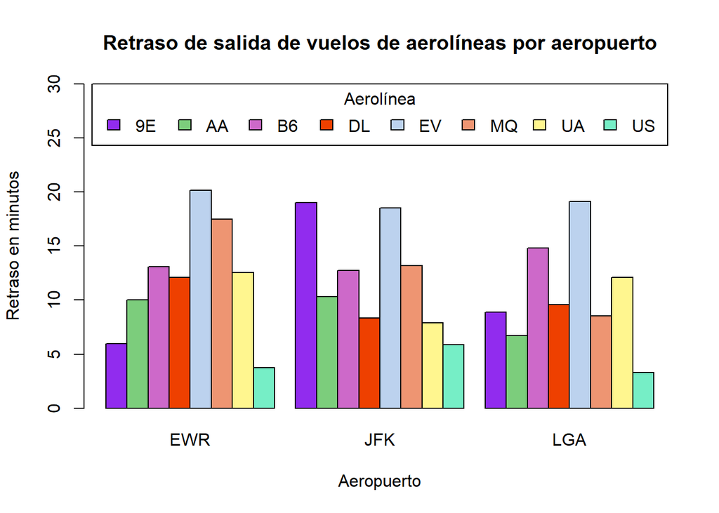

```r
barplot(as.matrix(py$dep_delay_df),
        main = "Retraso de salida de vuelos de aerolíneas por aeropuerto",
        names.arg = c('EWR', 'JFK', 'LGA'),
        xlab = "Aeropuerto",
        ylab = "Retraso en minutos",
        col = c('purple2','palegreen3','orchid3','orangered2','lightsteelblue2','lightsalmon2', 'khaki1', 'aquamarine2'),
        beside = TRUE,
        legend.text = TRUE,
        args.legend = list(title = "Aerolínea", x = "top", horiz = TRUE),
        ylim = c(0, 30))
```

Del gráfico podemos observar que la aerolínea **9E** parecería tener problemas para salir a horario en el aeropuerto **JFK** en comparación con los otros dos aeropuertos, mientras que el promedio elevado de retrasos de salida de la aerolínea **EV** se ve que no depende de los aeropuertos del que parten sus aviones. Lo mismo ocurre con la aerolínea **US** que es la que tiene una tasa menor del promedio de retrasos de salida de sus vuelos, independientemente del aeropuerto en cuestión.

## Retraso de salida de vuelos por aeropuerto

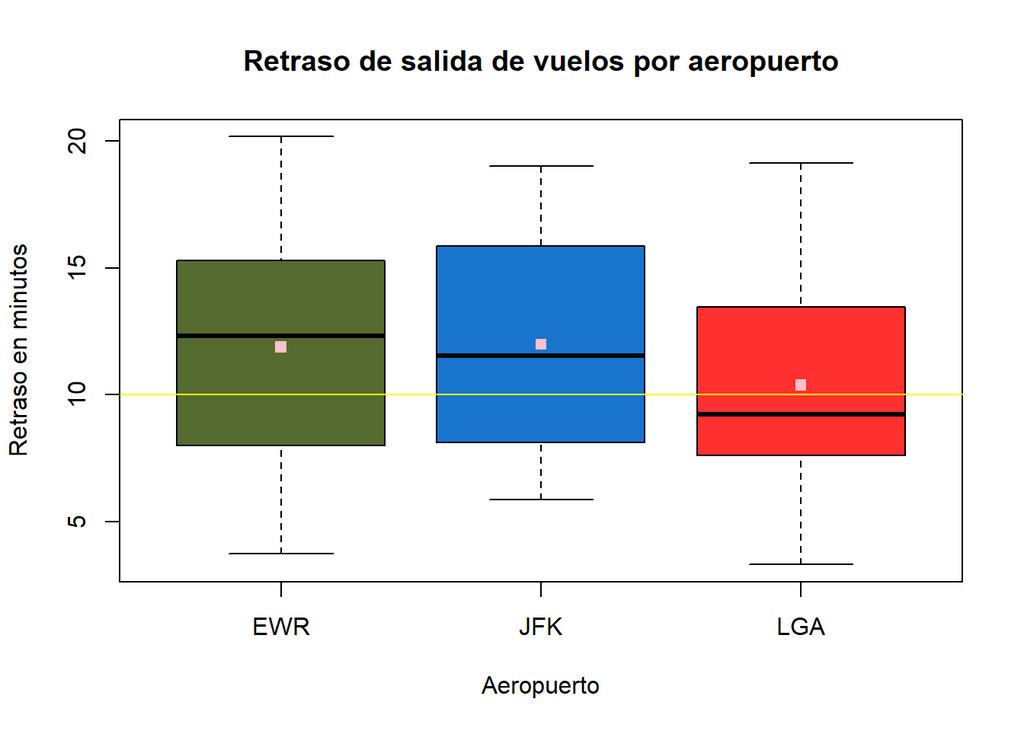

```r
boxplot(py$dep_delay_df,
        main = "Retraso de salida de vuelos por aeropuerto",
        names = c('EWR', 'JFK', 'LGA'),
        xlab = "Aeropuerto",
        ylab = "Retraso en minutos",
        col = c("darkolivegreen", "dodgerblue3", "firebrick1"))
means = apply(py$dep_delay_df, 2, mean)
points(means, col = c("pink"), pch = 15)
abline(h = 10, col = c("yellow"))
```

Observando el boxplot, vemos que el aeropuerto **EWR** presenta los mayores retrasos en la partida de sus vuelos por tener más de la mitad del promedio de retrasos igual o superior a los **12 minutos**.

## Distancia de recorrido por aerolíneas

```python
distance_df = r.data
distance_df = distance_df.pivot_table(["distance"], index = ["carrier"], aggfunc = np.mean)
distance_df = distance_df.dropna()
distance_df
```

```
##             distance
## carrier
## 9E        530.235753
## AA       1340.235999
## AS       2402.000000
## B6       1068.621525
## DL       1236.901206
## EV        562.991730
## F9       1620.000000
## FL        664.829448
## HA       4983.000000
## MQ        569.532712
## OO        500.812500
## UA       1529.114873
## US        553.456272
## VX       2499.482177
## WN        996.269084
## YV        375.033278
```

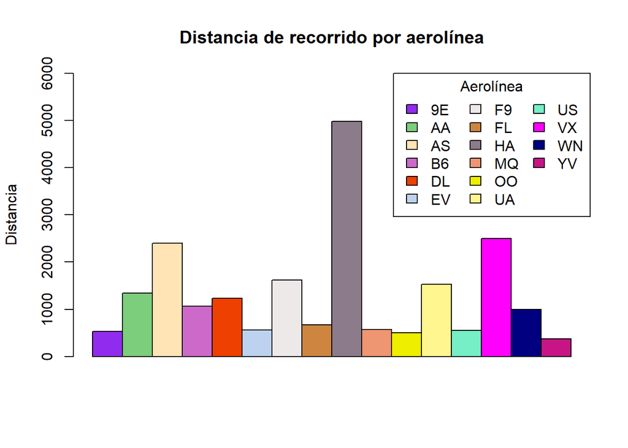

```r
barplot(as.matrix(py$distance_df),
        main = "Distancia de recorrido por aerolínea",
        names.arg = "",
        xlab = "",
        ylab = "Distancia",
        col = c('purple2','palegreen3','moccasin','orchid3','orangered2','lightsteelblue2','snow2','tan3',
                'thistle4','lightsalmon2','yellow2','khaki1','aquamarine2','magenta','navyblue','mediumvioletred'),
        beside = TRUE,
        legend.text = TRUE,
        args.legend = list(title = "Aerolínea", x = "topright", ncol = 3),
        ylim = c(0,6000))
```